# Linear Regression 1

John Yuill

October 23, 2016

### Purpose

- collect practices around correlation and regression
- primary initial source is Marin Stats R video on YT
  - https://www.youtube.com/watch?v=66z_MRwtFJM

#### Collect data and have a look

```r
library(ggplot2)
lungcap <- read.csv("data-source/LungCapData.csv",header=TRUE, stringsAsFactors=FALSE)
str(lungcap)
```

```
## 'data.frame':    725 obs. of  6 variables:
##  $ LungCap  : num  6.47 10.12 9.55 11.12 4.8 ...
##  $ Age      : int  6 18 16 14 5 11 8 11 15 11 ...
##  $ Height   : num  62.1 74.7 69.7 71 56.9 58.7 63.3 70.4 70.5 59.2 ...
##  $ Smoke    : chr  "no" "yes" "no" "no" ...
##  $ Gender   : chr  "male" "female" "female" "male" ...
##  $ Caesarean: chr  "no" "no" "yes" "no" ...
```

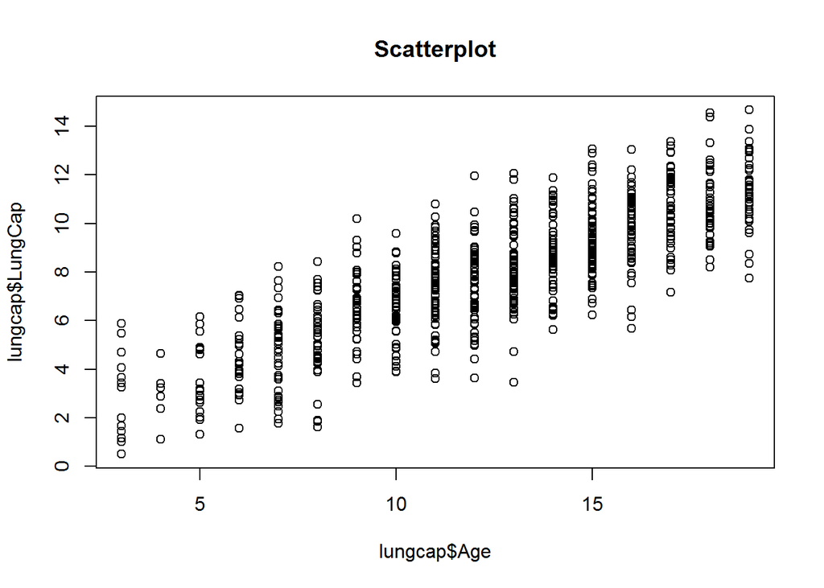

```r
plot(lungcap$Age, lungcap$LungCap, main="Scatterplot")
```

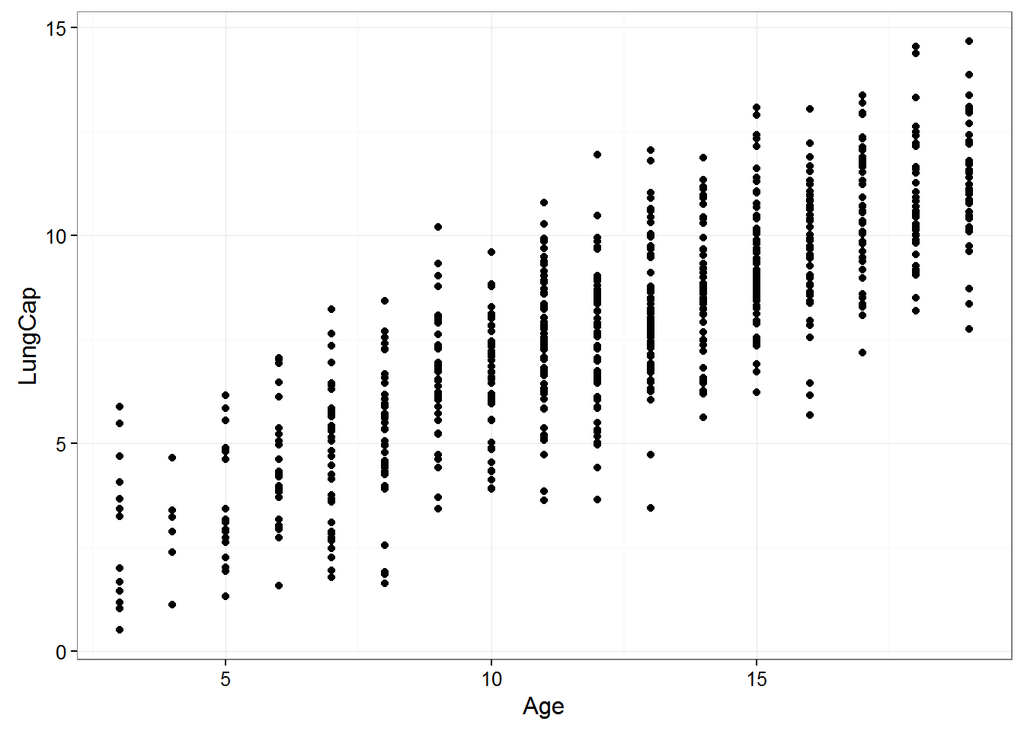

```r
ggplot(data=lungcap, aes(x=Age,y=LungCap))+geom_point()+theme_bw()
```

#### Check Correlation and Create Linear Model

- Check correlation

```r
cor(lungcap$Age,lungcap$LungCap)
```

```
## [1] 0.8196749
```

- Generate a linear model

```r
mod <- lm(lungcap$LungCap ~ lungcap$Age)
summary(mod)
```

```
##
## Call:
## lm(formula = lungcap$LungCap ~ lungcap$Age)
##
## Residuals:
##     Min      1Q  Median      3Q     Max
## -4.7799 -1.0203 -0.0005  0.9789  4.2650
##
## Coefficients:
##             Estimate Std. Error t value Pr(>|t|)
## (Intercept)  1.14686    0.18353   6.249 7.06e-10 ***
## lungcap$Age  0.54485    0.01416  38.476  < 2e-16 ***
## ---
## Signif. codes:  0 '***' 0.001 '**' 0.01 '*' 0.05 '.' 0.1 ' ' 1
##
## Residual standard error: 1.526 on 723 degrees of freedom
## Multiple R-squared:  0.6719, Adjusted R-squared:  0.6714
## F-statistic:  1480 on 1 and 723 DF,  p-value: < 2.2e-16
```

- [sidebar] determine attributes available for the mod object

```r
attributes(mod)
```

```
## $names
##  [1] "coefficients"  "residuals"     "effects"       "rank"
##  [5] "fitted.values" "assign"        "qr"            "df.residual"
##  [9] "xlevels"       "call"          "terms"         "model"
##
## $class
## [1] "lm"
```

- check coefficients

```r
mod$coef
```

```
## (Intercept) lungcap$Age
##   1.1468578   0.5448484
```

```r
coef(mod)
```

```
## (Intercept) lungcap$Age
##   1.1468578   0.5448484
```

- get confidence intervals
  - 95% is default

```r
confint(mod)
```

```
##                 2.5 %    97.5 %
## (Intercept) 0.7865454 1.5071702
## lungcap$Age 0.5170471 0.5726497
```

```
+ adjust to 99%
```

```r
confint(mod, level=0.99)
```

```
##                 0.5 %    99.5 %
## (Intercept) 0.6728686 1.6208470
## lungcap$Age 0.5082759 0.5814209
```

- scatterplot with linear regression line

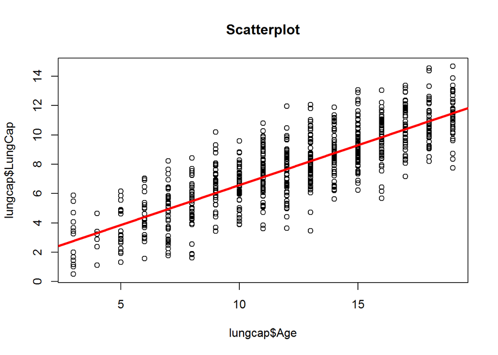

```r
plot(lungcap$Age, lungcap$LungCap, main="Scatterplot")
abline(mod, col=2, lwd=3)
```

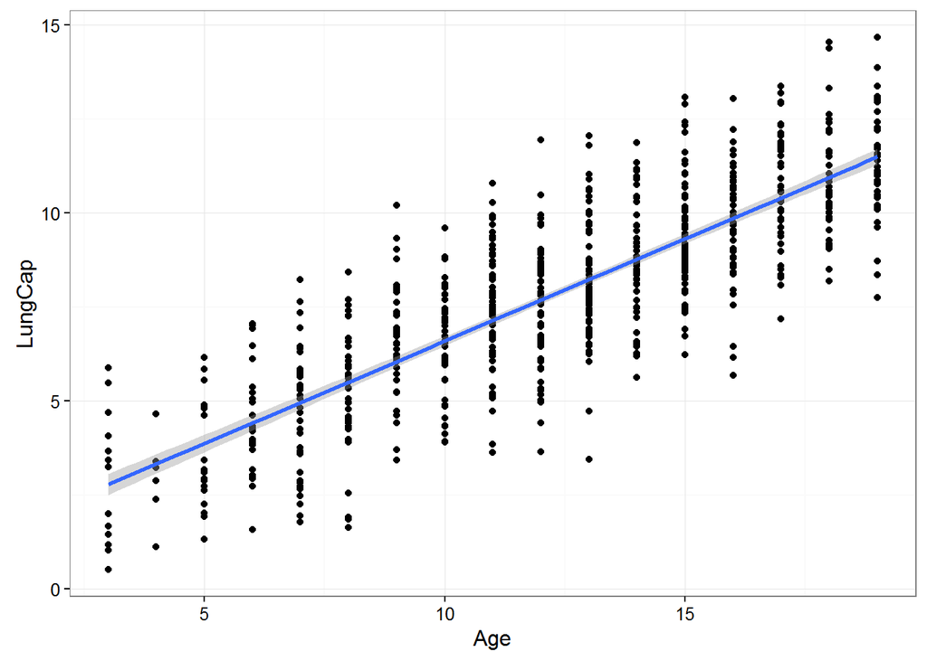

```r
ggplot(data=lungcap, aes(x=Age,y=LungCap))+geom_point()+
theme_bw()+
geom_smooth(method=lm, se=TRUE)
```

#### Check validity of assumptions

Assumptions 1. Y-values (or the errors) are independent + requires knowledge of the study design or data collection 2. Y-values can be expressed as a linear function of the X variable 3. Variation of observations around the regression line (residual standard errors (SE)) is constant (homoscedasticity) 4. For given value of X, Y values (or the error) are normally distributed

- validation of #1 requires knowledge of the study design or data collected
- others can be checked by examining the residuals or errors

##### R has built-in regression diagnostic plots

Diagnostic plots * unless mfrow is set, plots require hitting ‘return’ in console  
* won’t run in R Markdown - will cause error

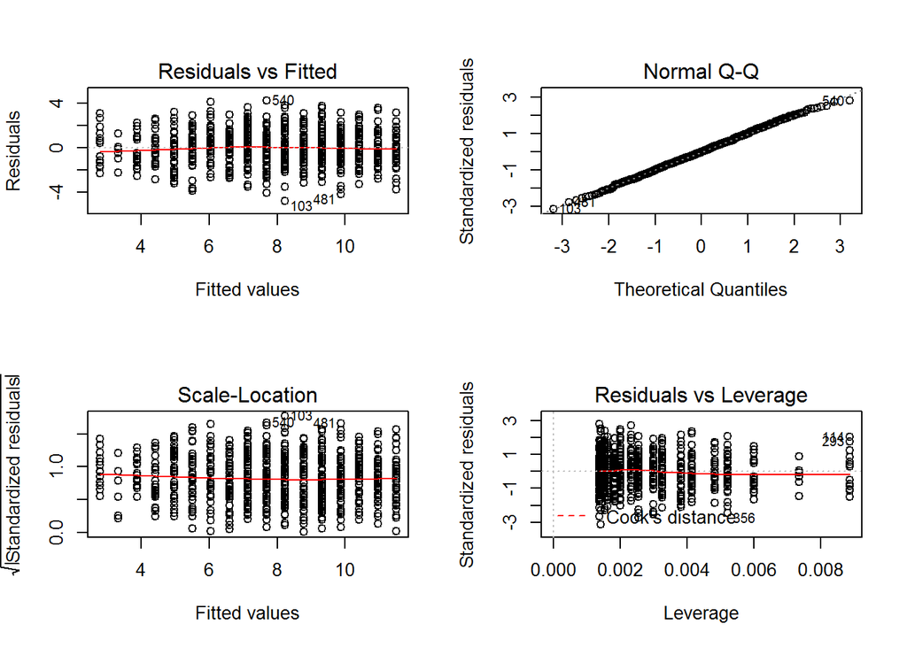

```r
par(mfrow=c(2,2))
plot(mod)
```

The Plots: 1. Residuals vs Fitted + should see no real pattern + line should be flat 2. Normal Q-Q + if errors are normally distributed, points should fall along line 3. Scale-Location 4. Residuals vs Leverage